# Time Series - Final Project

by Aleksandra Piłat, Jędrzej Sarna, Wojciech Szyszka, Piotr Lachowicz

12.01.2024

# TASK 1:

Consider the monthly *numbers of visitors* (see file dane_AJWP.csv at UPeL)).  
1. Make *numbers of visitors* forecasts for each month of the year 2024.

## SOLUTION of TASK 1

First let’s define useful functions.

```r
periodogram <- function(TS)
{
  n = length(TS)
  Per= Mod(fft(TS-mean(TS)))^2/n
  Freq = (1:n -1)/n
  plot(Freq[1:n], Per[1:n], type='h', lwd=2, ylab="Periodogram",
       xlab="Frequency")

}
```

Function periodogram plots the periodogram of time series TS.

```r
periods <- function(TS)
{
  n = length(TS)
  Per= Mod(fft(TS-mean(TS)))^2/n  #
  Freq = (1:n -1)/n
  nn=n/2
  y = cbind(1:nn, Freq[1:nn], 1/Freq[1:nn],Per[1:nn]); y[order(y[,4],decreasing = TRUE),]
}
```

Function periods shows possible periods.

```r
ACF_and_PACF <- function(TS, LagMax)
{
  par(mfrow = c(1, 2))
  acf(na.omit(TS), lag.max = LagMax)
  pacf(na.omit(TS), lag.max = LagMax)
  par(mfrow = c(1, 1))
}
```

Function ACF_and_PAC plots ACF and PACF.

PROPER TASK:

We import the data and plot it.

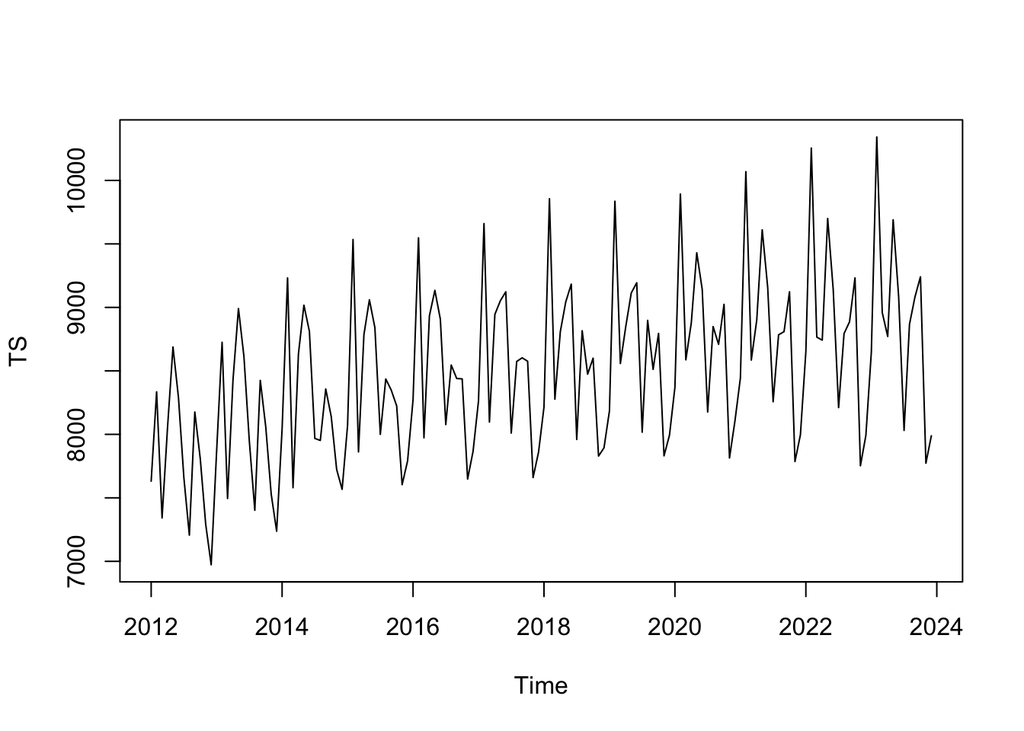

```r
data <- read.csv(file = "/Users/jedrzejsarna/Desktop/II stopien 3 semestr/Time Series Analysis/dane_AJWP.csv")
TS <- ts(data$numbers.of.V., start = c(2012, 1), frequency = 12)
par(mfrow=c(1,1))
plot(TS)
```

Now we check if the data are seasonal by using periodogram.

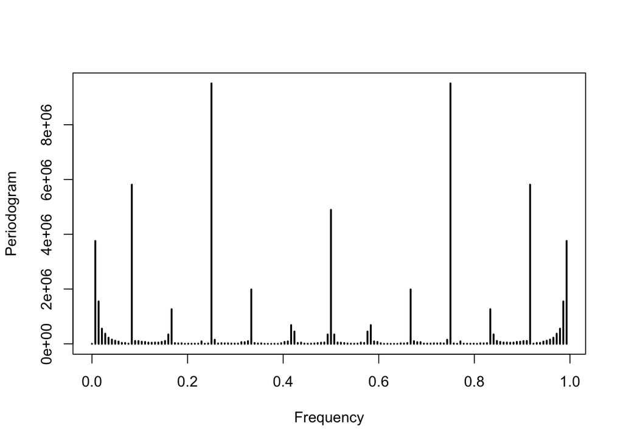

```r
periodogram(TS)
```

```r
periods(TS)
```

```
##       [,1]        [,2]       [,3]         [,4]
##  [1,]   37 0.250000000   4.000000 9.509754e+06
##  [2,]   13 0.083333333  12.000000 5.810973e+06
##  [3,]    2 0.006944444 144.000000 3.754844e+06
##  [4,]   49 0.333333333   3.000000 1.984593e+06
##  [5,]    3 0.013888889  72.000000 1.548211e+06
##  [6,]   25 0.166666667   6.000000 1.262829e+06
##  [7,]   61 0.416666667   2.400000 6.821269e+05
##  [8,]    4 0.020833333  48.000000 5.532476e+05
##  [9,]   62 0.423611111   2.360656 4.480043e+05
## [10,]    5 0.027777778  36.000000 3.703600e+05
## [11,]   24 0.159722222   6.260870 3.431302e+05
## [12,]   72 0.493055556   2.028169 3.415329e+05
## [13,]    6 0.034722222  28.800000 2.238086e+05
## [14,]    7 0.041666667  24.000000 1.559653e+05
```

[output cut: 58 more lines]

As we can see, the biggest value in periodogram is for period = 4 months and the second biggest value is for period = 12 months.

We decide to take period = 12 months as it is very typical for this type of data (number of visitors).

We remove seasonality by differentiating and plot the obtained time series.

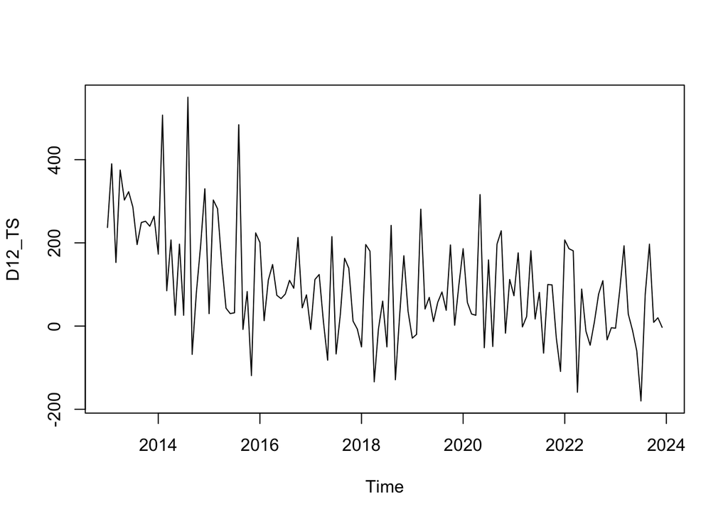

```r
D12_TS <- diff(TS, lag = 12)
plot(D12_TS)
```

We remove the trend.

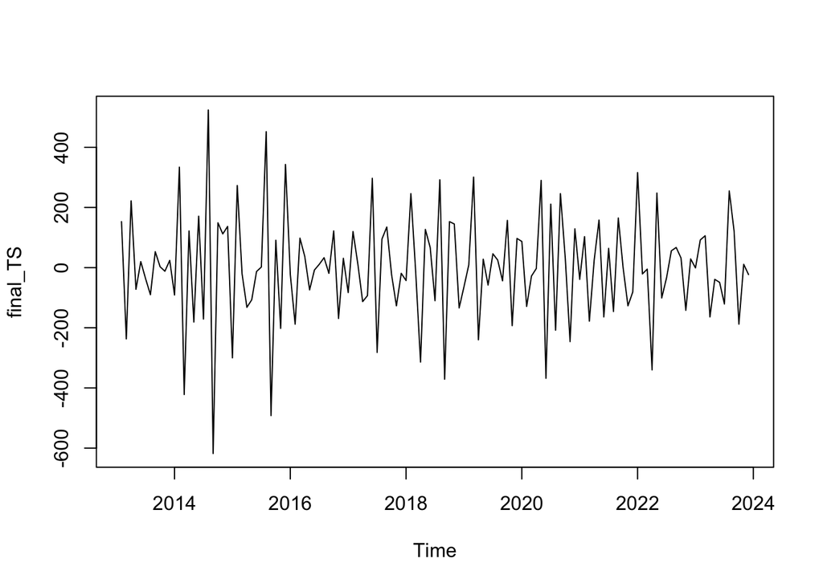

```r
final_TS <- diff(D12_TS, lag = 1)
plot(final_TS)
```

Now we plot the ACF and PACF of our final data.

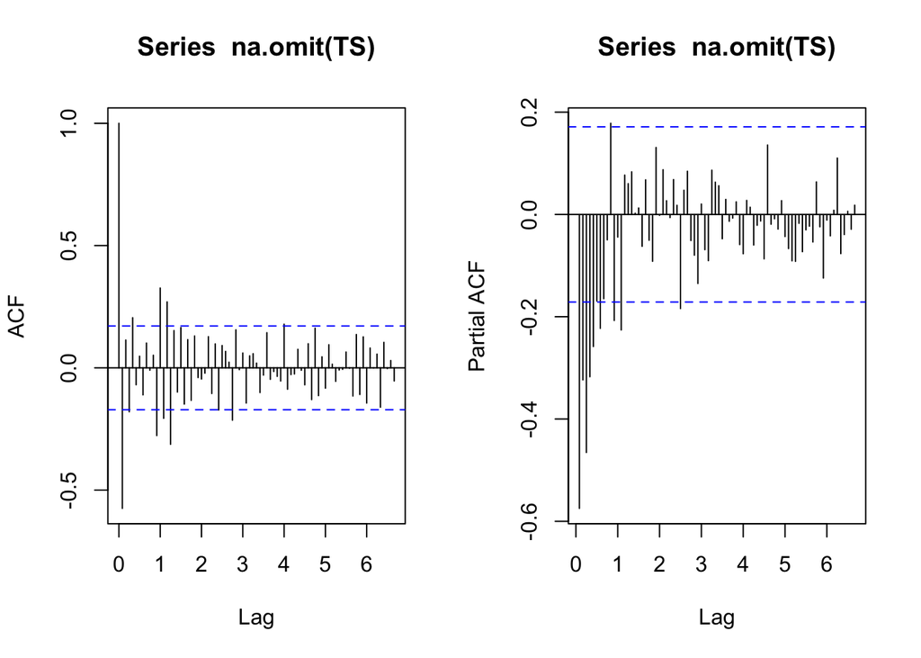

```r
ACF_and_PACF(final_TS, 80)
```

We will try to fit the data to some SARIMA $(p,d,q)×(P,D,Q)_s$ model (with s = 12).

Looking at the ACF and PACF plots we see that:

- We can try P=1, Q=0 or P=0. Q=1.
- PACF tails off and ACF cuts off at lag 1, 3 or maybe 4. So we consider p=0 and:
  - q=1,
  - q=3,
  - q=4.

P = 1, Q = 0

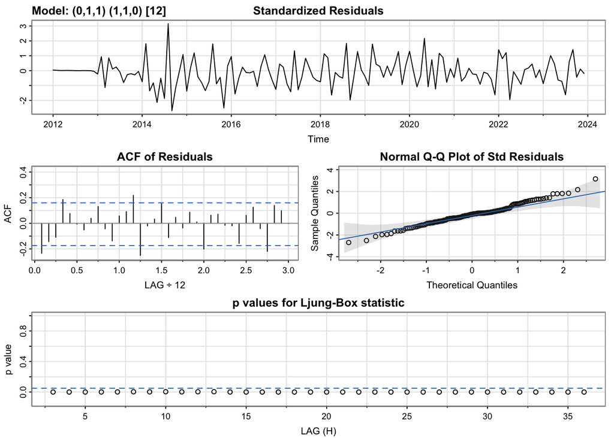

```
##      Estimate     SE  t.value p.value
## ma1   -0.9179 0.0277 -33.0824   0e+00
## sar1   0.3299 0.0844   3.9079   1e-04
```

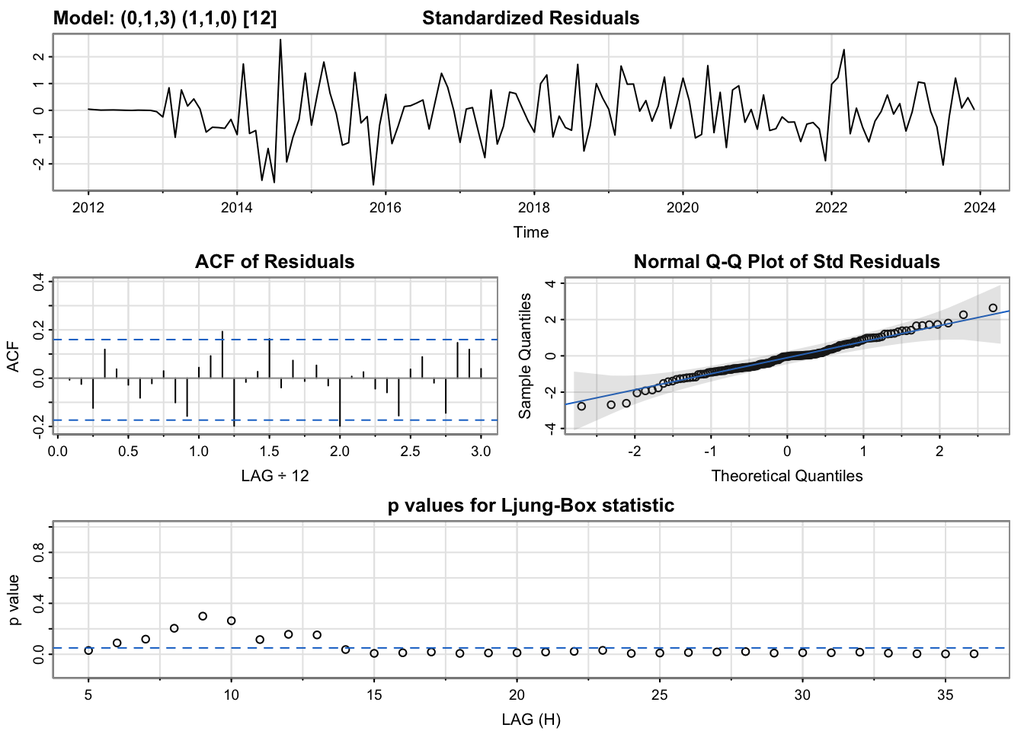

```
##      Estimate     SE  t.value p.value
## ma1   -1.2801 0.0827 -15.4870  0.0000
## ma2    0.1934 0.1268   1.5249  0.1298
## ma3    0.1998 0.0744   2.6871  0.0082
## sar1   0.3286 0.0852   3.8575  0.0002
```

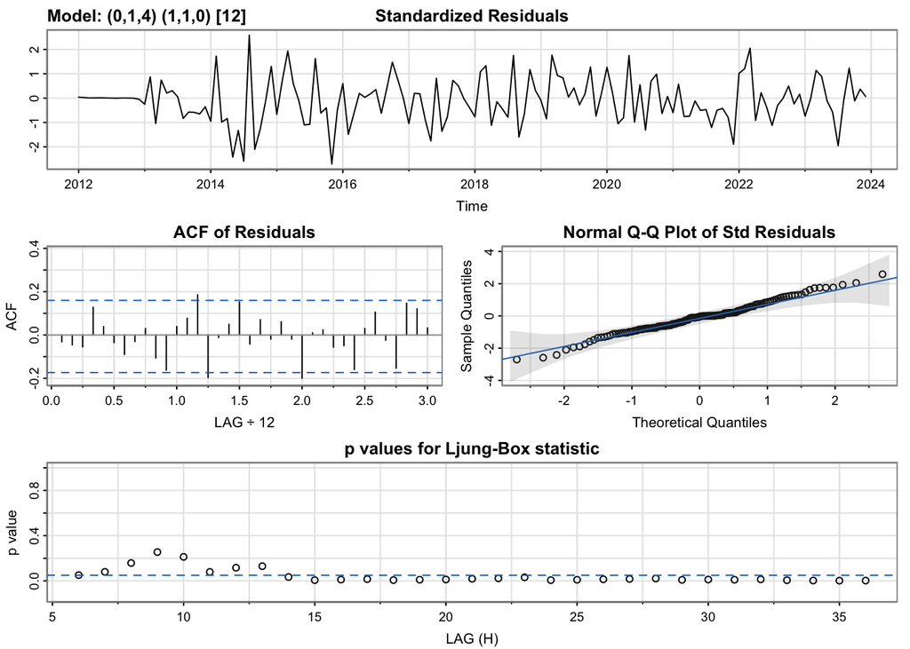

```
##      Estimate     SE  t.value p.value
## ma1   -1.2444 0.0931 -13.3617  0.0000
## ma2    0.1724 0.1344   1.2832  0.2018
## ma3    0.0927 0.1442   0.6424  0.5218
## ma4    0.0973 0.1139   0.8544  0.3945
## sar1   0.3045 0.0901   3.3803  0.0010
```

```r
library(astsa)
for(i in c(1,3,4))
{
  mA<-sarima(TS,0,1,i,1,1,0,12)
  print(mA$ttable)
}
```

P = 0, Q = 1

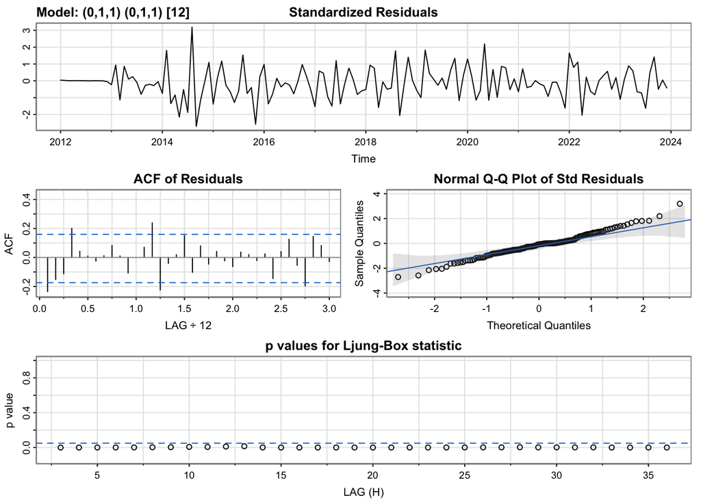

```
##      Estimate     SE  t.value p.value
## ma1   -0.9171 0.0274 -33.4896       0
## sma1   0.4029 0.0789   5.1047       0
```

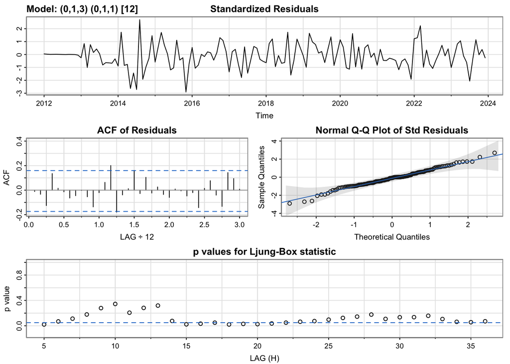

```
##      Estimate     SE  t.value p.value
## ma1   -1.2807 0.0823 -15.5589  0.0000
## ma2    0.1913 0.1268   1.5086  0.1339
## ma3    0.2037 0.0738   2.7594  0.0066
## sma1   0.4153 0.0812   5.1123  0.0000
```

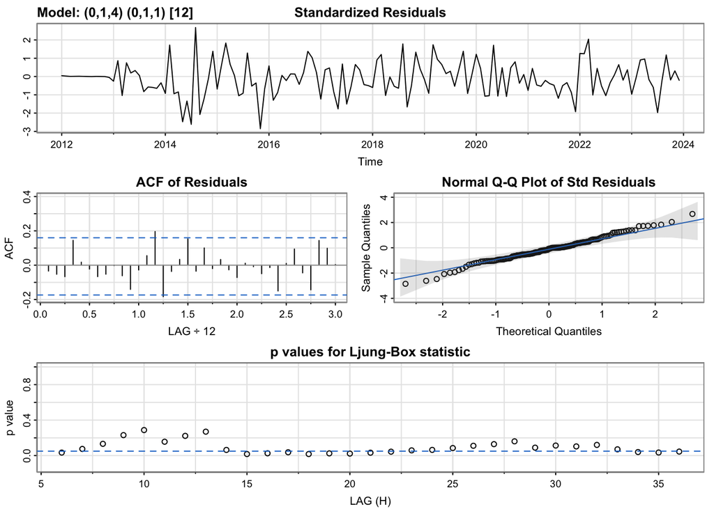

```
##      Estimate     SE  t.value p.value
## ma1   -1.2463 0.0953 -13.0776  0.0000
## ma2    0.1691 0.1351   1.2518  0.2130
## ma3    0.1142 0.1400   0.8155  0.4163
## ma4    0.0813 0.1097   0.7413  0.4599
## sma1   0.3990 0.0859   4.6468  0.0000
```

```r
for(i in c(1,3,4))
{
  mA<-sarima(TS,0,1,i,0,1,1,12)
  print(mA$ttable)
}
```

Making predicions.

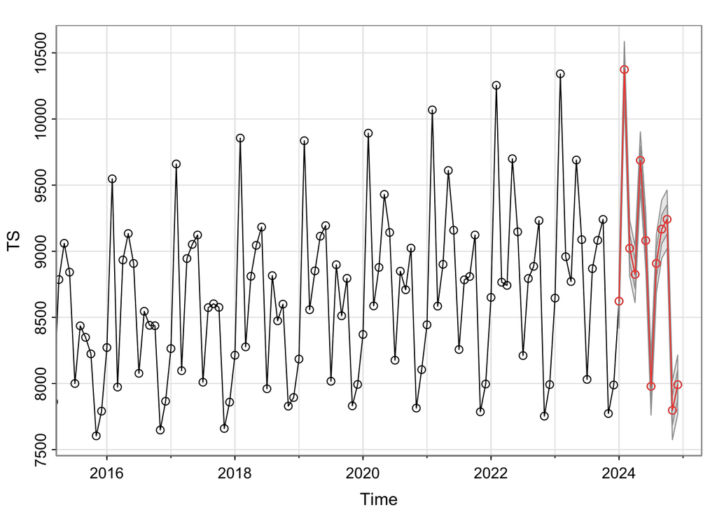

```r
pred<-sarima.for(TS,n.ahead=12,0,1,3,0,1,1,12)
```

# TASK 2:

Consider the [Wojciech’s time series from Lab 1 task 4.2](https://upel.agh.edu.pl/mod/forum/discuss.php?d=8438) (Weekly closing prices from WSE of the PKN Orlen) 1. Make all necessary transformations to get a stationary time series (noise).  
2. If possible, choose the ARMA (p, q) model for stationary noise.

## SOLUTION of TASK 2

In this analysis, we aim to transform a financial time series dataset representing weekly closing prices of PKN Orlen from January 2009. The objective is to achieve stationarity and subsequently identify a suitable ARIMA (p, q) model for the stationary noise.

### Preparation of data for analysis

Firstly, we install and load essential R libraries, including `tidyverse`, `tseries`, `conflicted`, and `forecast`, to ensure we have the necessary tools for data manipulation, statistical analysis, and forecasting.

```r
# install.packages(c("tidyverse", "tseries", "conflicted", "forecast"))
library(conflicted)
library(tidyverse)
library(tseries)
library(forecast)
```

To prevent conflicts in function names between loaded libraries, we use the `conflicted` package to resolve any potential naming clashes.

```r
conflict_prefer("filter", "stats")
```

```
## [conflicted] Will prefer stats::filter over any other package.
```

```r
conflict_prefer("lag", "stats")
```

```
## [conflicted] Will prefer stats::lag over any other package.
```

We read the financial data from the provided CSV file, named “PKN.WA.csv,” into a data frame named `data`.

```r
data <- read.csv("/Users/jedrzejsarna/Desktop/II stopien 3 semestr/Time Series Analysis/PKN.WA.csv")
```

We create a time series (`TS`) object from the closing prices, specifying a frequency of 52 (assuming weekly data) and a starting date of January 2009.

```r
TS <- ts(data$Close, frequency = 52, start = c(2009, 1))
```

We visualize the original time series to gain insights into the patterns of closing prices over time.

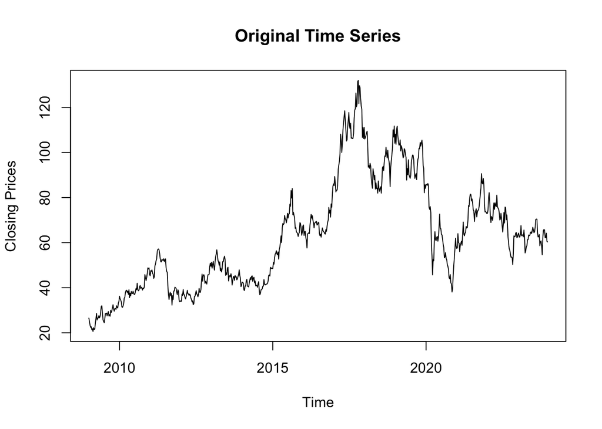

```r
plot(TS, main = "Original Time Series", ylab = "Closing Prices", xlab = "Time")
```

### Achieving Stationarity

As you can see from the chart, for the first few years Closing Price had an upward trend, whereas since 2017 the trend has been downward. So we decided to apply differencing to remove the trend from the time series.

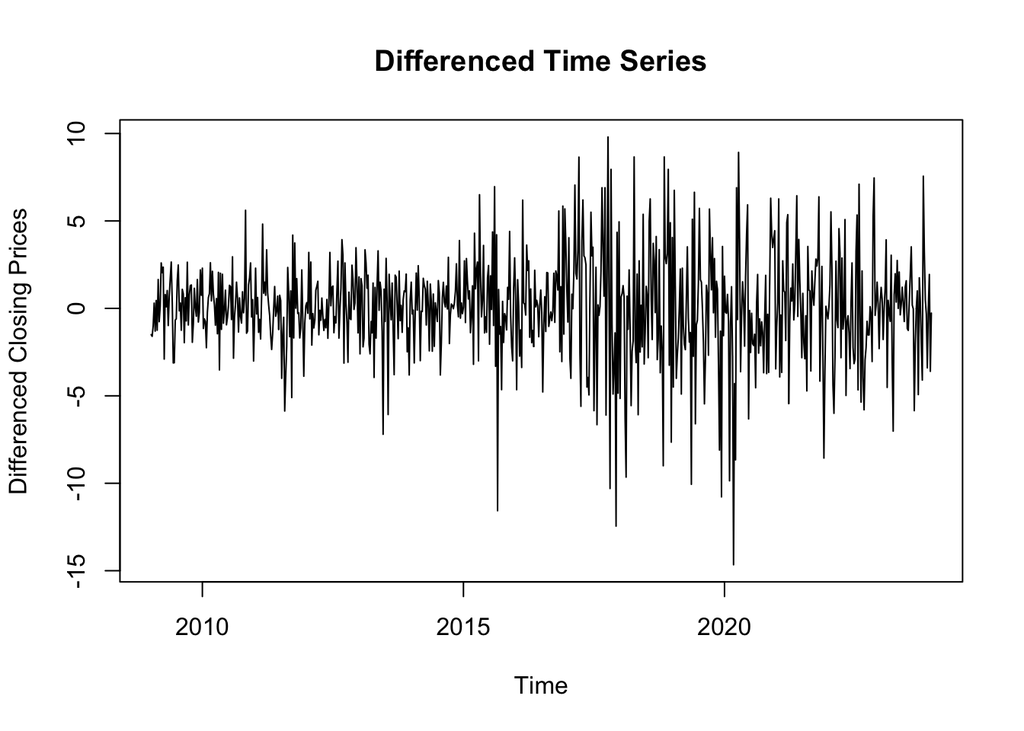

```r
TS_diff <- diff(TS)
plot(TS_diff, main = "Differenced Time Series", ylab = "Differenced Closing Prices", xlab = "Time")
```

Once the trend has been removed, it is difficult for us to determine whether there is seasonality from the graph above.

For further analysis of seasonality, let us draw a graph Autocorrelation Seasonal Function (ACF).

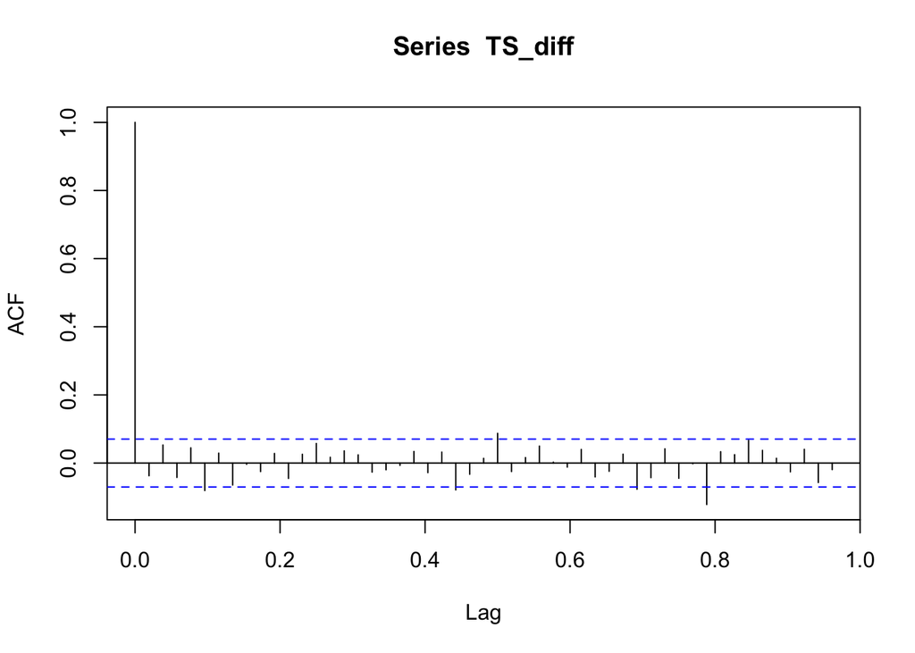

```r
acf(TS_diff, lag.max = 50)
```

After analysing the ACF chart, we recognise that our data lacks seasonality.

Next we perform an Augmented Dickey-Fuller test on the differenced time series to check for stationarity.

The Augmented Dickey-Fuller (ADF) test is a statistical test used to assess the stationarity of a time series data set. It helps determine whether differencing the time series has made it stationary or if further transformation is needed.

**Null Hypothesis (H0)**: The time series has a unit root, indicating non-stationarity.  
**Alternate Hypothesis (H1)**: The time series does not have a unit root, indicating stationarity.

If the test statistic is less than the critical value, we may reject the null hypothesis, suggesting that the time series is stationary. If the test statistic is greater than the critical value, we fail to reject the null hypothesis, indicating that the time series is non-stationary.

```r
adf.test(TS_diff)
```

```
##
##  Augmented Dickey-Fuller Test
##
## data:  TS_diff
## Dickey-Fuller = -9.2832, Lag order = 9, p-value = 0.01
## alternative hypothesis: stationary
```

Since the p-value is less than 0.05, we decide to reject the null hypothesis and conclude that our time series is stationary.

### ARIMA Modeling

To define an ARIMA model with a specific order (p, 0, q) let us draw the autocorrelation and partial autocorrelation function plots.

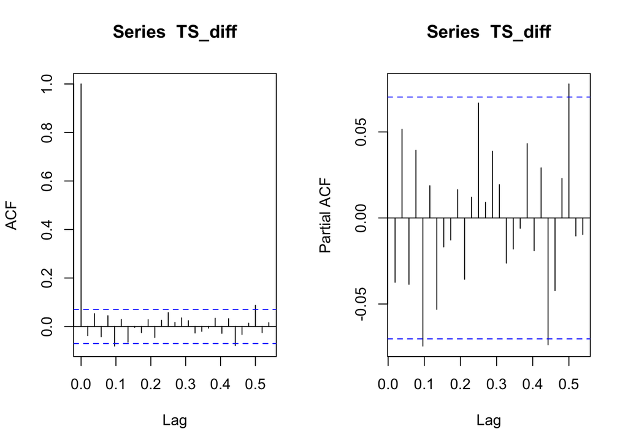

```r
par(mfrow=c(1,2))
acf(TS_diff)
pacf(TS_diff)
```

Based on the graph above, we choose an ARIMA model with an order of (1, 0, 5).

```r
p <- 1
q <- 5
arima_model <- arima(TS_diff, order = c(p, 0, q))
```

After fitting the ARIMA model, it’s essential to assess whether the residuals (the differences between the observed and predicted values) exhibit any significant autocorrelation. The Ljung-Box test is a statistical test used for this purpose.

The Ljung-Box test helps us determine whether the residuals of the model are similar to white noise, which is a crucial assumption for a well-fitted time series model.

**Null Hypothesis (H0)**: The null hypothesis assumes that there is no autocorrelation in the residuals, indicating that they resemble white noise.  
**Alternate Hypothesis (H1)**:The alternative hypothesis suggests the presence of autocorrelation in the residuals, indicating that the model has not captured all the patterns in the data.

If the test statistic is small and the associated p-value is greater than a chosen significance level, we fail to reject the null hypothesis. If the test statistic is large and the p-value is less than the significance level, we reject the null hypothesis, indicating significant autocorrelation.

```r
ljung_box_test <- Box.test(arima_model$residuals, lag = 20, type = "Ljung-Box")
cat("Ljung-Box Test p-value:", ljung_box_test$p.value, "\n")
```

```
## Ljung-Box Test p-value: 0.9614724
```

The high p-value (0.9614724) suggests that we fail to reject the null hypothesis.

The Ljung-Box Test supports the adequacy of the ARIMA model for our time series data. The non-rejection of the null hypothesis indicates that the residuals are consistent with the assumption of white noise, affirming the reliability of our modeling approach.

In summary, with a p-value of 0.9614724, we have no compelling reason to believe that there is significant autocorrelation in the residuals, providing confidence in the effectiveness of the ARIMA model.